# R Notebook

```r
setwd('~/Documents/ML')
```

[output not shown]

```r
library(dplyr)
library(class)
library(caret)
df <- read.csv('glass.data.txt', header = F)
colnames(df) <- c('ID',"RI",'Na',"Mg","Al","Si","K", "Ca", "Ba", "Fe", "Type")
```

3. (5 pts) Create a histogram of the Na column and overlay a normal curve; visually determine whether the data is normally distributed. You may use the code from this tutorial. Does the k-NN algorithm require normally distributed data or is it a non-parametric method? Comment on your findings.

The data is normally distributed. The k-NN algorithm does not require normally distributed data. It is a non-parametric method.

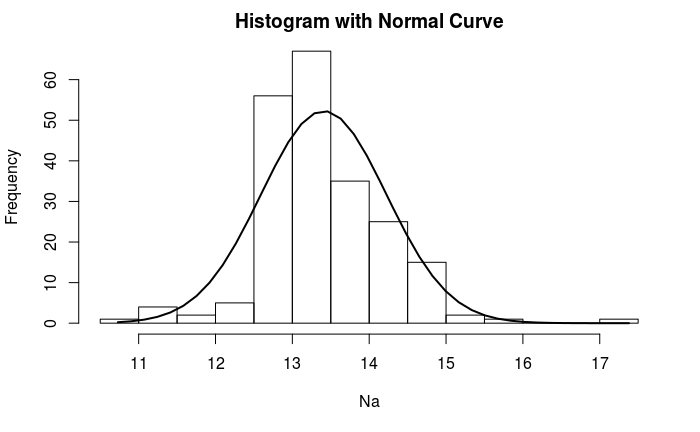

```r
x <- df$Na
h<-hist(x, breaks=10, xlab="Na",
    main="Histogram with Normal Curve")
xfit<-seq(min(x),max(x),length=40)
yfit<-dnorm(xfit,mean=mean(x),sd=sd(x))
yfit <- yfit*diff(h$mids[1:2])*length(x)
lines(xfit, yfit, lwd=2)
```

4. (5 pts) After removing the ID column (column 1), normalize the first two columns in the data set using min-max normalization.

```r
df_norm <- df[,-1]
normalize <- function(x) {
return ((x - min(x)) / (max(x) - min(x))) }
df_n <- as.data.frame(lapply(df_norm[1:2], normalize))
head(df_n)
```

|  | RI | Na |
| --- | --- | --- |
| 1 | 0.4328358 | 0.4375940 |
| 2 | 0.2835821 | 0.4751880 |
| 3 | 0.2208077 | 0.4210526 |
| 4 | 0.2857770 | 0.3729323 |
| 5 | 0.2752414 | 0.3819549 |
| 6 | 0.2111501 | 0.3097744 |

5. (5 pts) Normalize the remaining columns, except the last one, using z-score standardization. The last column is the glass type and so it is excluded.

```r
z_score <- function(x){
  return((x - mean(x))/sd(x))
}
dd <- as.data.frame(lapply(df_norm[3:9], z_score))
data <- cbind(df_n,dd,Type = df_norm$Type)
```

6. (5 pts) The data set is sorted, so creating a validation data set requires random selection of elements. Create a stratified sample where you randomly select 50% of each of the cases for each glass type to be part of the validation data set. The remaining cases will form the training data set.

```r
# Check the nymber of cases for each glass type
data %>% group_by(Type) %>% summarise(rows = length(Type))
```

| Type | rows |
| --- | --- |
| 1 | 70 |
| 2 | 76 |
| 3 | 17 |
| 5 | 13 |
| 6 | 9 |
| 7 | 29 |

```r
#install.packages("kimisc")
library(kimisc)
# Select half of the cases for each glass typr for the training data set
df.1 <- sample.rows(subset(data, Type == "1"), 35)
df.2 <- sample.rows(subset(data, Type == "2"), 38)
df.3 <- sample.rows(subset(data, Type == "3"), 9)
df.5 <- sample.rows(subset(data, Type == "5"), 6)
df.6 <- sample.rows(subset(data, Type == "6"), 5)
df.7 <- sample.rows(subset(data, Type == "7"), 14)
test_df <- rbind(df.1,df.2,df.3,df.5,df.6,df.7)
train_df <- anti_join(data, test_df)
```

Implement the k-NN algorithm in R (do not use an implementation of k-NN from a package) and use your algorithm with a k=10 to predict the glass type for the following two cases

The glass type for the first unknown case is 1 and for the second case, it is 6

```r
unk1 <- c(1.51621,12.53,3.48,1.39,73.39,0.60,8.55,0.00,0.05)
unk2 <- c(1.5098,12.77,1.85,1.81,72.69,0.59,10.01,0.00,0.01)
# Normalizing the new cases
norm1 <- function(x) {
return ((x - 1.5112) / (1.5339 - 1.5112)) }
unk1[1] <- norm1(unk1[1])
unk2[1] <- norm1(unk2[1])
norm2 <- function(x) {
return ((x - 10.73) / (17.38 - 10.73)) }
unk1[2] <- norm2(unk1[2])
unk2[2] <- norm2(unk2[2])
unk1[3] <- (unk1[3] - 2.6845)/1.4424
unk1[4] <- (unk1[4] - 1.4449)/0.4993
unk1[5] <- (unk1[5] - 72.6509)/0.7745
unk1[6] <- (unk1[6] - 0.4971)/0.6522
unk1[7] <- (unk1[7] - 8.9570)/1.4232
unk1[8] <- (unk1[8] - 0.1750)/0.4972
unk1[9] <- (unk1[9] - 0.0570)/0.0974
unk2[3] <- (unk2[3] - 2.6845)/1.4424
unk2[4] <- (unk2[4] - 1.4449)/0.4993
unk2[5] <- (unk2[5] - 72.6509)/0.7745
unk2[6] <- (unk2[6] - 0.4971)/0.6522
unk2[7] <- (unk2[7] - 8.9570)/1.4232
unk2[8] <- (unk2[8] - 0.1750)/0.4972
unk2[9] <- (unk2[9] - 0.0570)/0.0974
unk1 <- as.data.frame(unk1)
unk1 <-t(unk1)
colnames(unk1) <- c("RI",'Na',"Mg","Al","Si","K", "Ca", "Ba", "Fe")
unk2 <- as.data.frame(unk2)
unk2 <- t(unk2)
colnames(unk1) <- c("RI",'Na',"Mg","Al","Si","K", "Ca", "Ba", "Fe")
# Calculating distances
dist <- function(p,q)
{
  d <- 0
  for (i in 1:length(p)) {
    d <- d + (p[i] - q[i])^2
  }
  dist <- sqrt(d)
}
neighbors <- function (data, unk)
{
   m <- nrow(data)
   ds <- numeric(m)
   #q <- as.numeric(unk)
   for (i in 1:m) {
     p <- data[i,c(1:9)]
   #  for (i in 1:nrow(unk))
      q <- unk[c(1:9)] #new
      ds[i] <- dist(p,q)
   }
   neighbors <- ds
}
k.closest <- function(neighbors,k)
{
  ordered.neighbors <- order(neighbors)
  k.closest <- ordered.neighbors[1:k]
}
#f <- k.closest(n,10)
Mode <- function(x)
{
  ux <- unique(x)
  ux[which.max(tabulate(match(x, ux)))]
}
#data$Type[f]
#Mode(data$Type[f])
knn_ <- function (train, u, k)
{
  nb <- neighbors(train,u)
  f <- k.closest(nb,k)
  knn_ <- Mode(train$Type[f])
}
nn1 <- knn_(data,unk1,10)
nn1
```

```
[1] 1
```

```r
nn2 <- knn_(data,unk2,10)
nn2
```

```
[1] 6
```

8. (10 pts) Apply the knn function from the class package with k=14 and redo the cases from Question (7).

```r
library(class)
head(train_df)
```

|  | RI | Na | Mg | Al | Si | K | Ca | Ba | Fe | Type |
| --- | --- | --- | --- | --- | --- | --- | --- | --- | --- | --- |
| 1 | 0.2835821 | 0.4751880 | 0.6346799 | -0.17006149 | 0.10207972 | -0.02615193 | -0.7918771 | -0.3520514 | -0.5850791 | 1 |
| 2 | 0.2857770 | 0.3729323 | 0.6970756 | -0.31026629 | -0.05284979 | 0.11184428 | -0.5178378 | -0.3520514 | -0.5850791 | 1 |
| 3 | 0.2756804 | 0.3864662 | 0.6346799 | -0.61070515 | 0.56686825 | 0.12717719 | -0.5529710 | -0.3520514 | -0.5850791 | 1 |
| 4 | 0.2809482 | 0.3413534 | 0.6346799 | -0.17006149 | 0.43776033 | 0.11184428 | -0.3913581 | -0.3520514 | 0.5438358 | 1 |
| 5 | 0.2001756 | 0.2992481 | 0.5376200 | 0.23052364 | 0.70888697 | 0.26517339 | -0.6091842 | -0.3520514 | 1.8780079 | 1 |
| 6 | 0.2080773 | 0.3233083 | 0.5168214 | -0.08994447 | 0.81217331 | 0.29583922 | -0.6372908 | -0.3520514 | 1.8780079 | 1 |

```r
head(test_df)
```

|  | RI | Na | Mg | Al | Si | K | Ca | Ba | Fe | Type |
| --- | --- | --- | --- | --- | --- | --- | --- | --- | --- | --- |
| 70 | 0.5201932 | 0.3879699 | 0.6208142 | -1.2516414 | -0.8533189 | -0.57813675 | 0.8523588 | -0.3520514 | -0.2771932 | 1 |
| 41 | 0.2976295 | 0.3097744 | 0.5653514 | -0.6507637 | 0.4894035 | 0.21917466 | -0.1313721 | -0.3520514 | -0.5850791 | 1 |
| 17 | 0.2936787 | 0.2932331 | 0.6832099 | -0.5706466 | 0.5926898 | 0.17317592 | -0.1805586 | -0.3520514 | -0.5850791 | 1 |
| 3 | 0.2208077 | 0.4210526 | 0.6000157 | 0.1904651 | 0.4377603 | -0.16414813 | -0.8270103 | -0.3520514 | -0.5850791 | 1 |
| 9 | 0.3525022 | 0.4977444 | 0.6208142 | -0.1500322 | -0.7371218 | 0.09651136 | -0.4616246 | -0.3520514 | -0.5850791 | 1 |
| 20 | 0.2721686 | 0.3443609 | 0.5930828 | 0.4909040 | 0.1020797 | 0.06584554 | -0.3632515 | -0.3520514 | 0.1333213 | 1 |

```r
data_n <- data[,1:9]
data_labels <- data[1:214,10]
#train_labels <- train_df[1:107, 10]
#test_labels <- test_df[1:107, 10]
prc_test_pred1 <- knn(train = data_n, test = unk1, cl = data_labels, k=14)
prc_test_pred1
```

```
[1] 1
Levels: 1 2 3 5 6 7
```

```r
prc_test_pred2 <- knn(train = data_n, test = unk2, cl = data_labels, k=14)
prc_test_pred2
```

```
[1] 6
Levels: 1 2 3 5 6 7
```

9. (10 pts) Determine the accuracy of the knn function with k=14 from the class package by applying it against each case in the validation data set. What is the percentage of correct classifications?

The percentage of correct classifications is 64.49%

```r
test_n <- test_df[,1:9]
test_labels <- test_df[1:107, 10]
test_pred <- knn(train = data_n, test = test_n, cl = data_labels, k=14)
library(gmodels)
CrossTable(x=test_labels, y=test_pred,prop.chisq = F)
```

```
   Cell Contents
|-------------------------|
|                       N |
|           N / Row Total |
|           N / Col Total |
|         N / Table Total |
|-------------------------|


Total Observations in Table:  107


             | test_pred
 test_labels |         1 |         2 |         3 |         5 |         6 |         7 | Row Total |
-------------|-----------|-----------|-----------|-----------|-----------|-----------|-----------|
           1 |        29 |         4 |         2 |         0 |         0 |         0 |        35 |
             |     0.829 |     0.114 |     0.057 |     0.000 |     0.000 |     0.000 |     0.327 |
             |     0.569 |     0.111 |     0.667 |     0.000 |     0.000 |     0.000 |           |
             |     0.271 |     0.037 |     0.019 |     0.000 |     0.000 |     0.000 |           |
-------------|-----------|-----------|-----------|-----------|-----------|-----------|-----------|
           2 |        13 |        24 |         0 |         0 |         0 |         1 |        38 |
             |     0.342 |     0.632 |     0.000 |     0.000 |     0.000 |     0.026 |     0.355 |
             |     0.255 |     0.667 |     0.000 |     0.000 |     0.000 |     0.077 |           |
             |     0.121 |     0.224 |     0.000 |     0.000 |     0.000 |     0.009 |           |
-------------|-----------|-----------|-----------|-----------|-----------|-----------|-----------|
           3 |         6 |         2 |         1 |         0 |         0 |         0 |         9 |
             |     0.667 |     0.222 |     0.111 |     0.000 |     0.000 |     0.000 |     0.084 |
             |     0.118 |     0.056 |     0.333 |     0.000 |     0.000 |     0.000 |           |
             |     0.056 |     0.019 |     0.009 |     0.000 |     0.000 |     0.000 |           |
-------------|-----------|-----------|-----------|-----------|-----------|-----------|-----------|
           5 |         0 |         3 |         0 |         2 |         0 |         1 |         6 |
             |     0.000 |     0.500 |     0.000 |     0.333 |     0.000 |     0.167 |     0.056 |
             |     0.000 |     0.083 |     0.000 |     1.000 |     0.000 |     0.077 |           |
             |     0.000 |     0.028 |     0.000 |     0.019 |     0.000 |     0.009 |           |
-------------|-----------|-----------|-----------|-----------|-----------|-----------|-----------|
           6 |         2 |         1 |         0 |         0 |         2 |         0 |         5 |
             |     0.400 |     0.200 |     0.000 |     0.000 |     0.400 |     0.000 |     0.047 |
             |     0.039 |     0.028 |     0.000 |     0.000 |     1.000 |     0.000 |           |
             |     0.019 |     0.009 |     0.000 |     0.000 |     0.019 |     0.000 |           |
-------------|-----------|-----------|-----------|-----------|-----------|-----------|-----------|
           7 |         1 |         2 |         0 |         0 |         0 |        11 |        14 |
             |     0.071 |     0.143 |     0.000 |     0.000 |     0.000 |     0.786 |     0.131 |
             |     0.020 |     0.056 |     0.000 |     0.000 |     0.000 |     0.846 |           |
             |     0.009 |     0.019 |     0.000 |     0.000 |     0.000 |     0.103 |           |
-------------|-----------|-----------|-----------|-----------|-----------|-----------|-----------|
Column Total |        51 |        36 |         3 |         2 |         2 |        13 |       107 |
             |     0.477 |     0.336 |     0.028 |     0.019 |     0.019 |     0.121 |           |
-------------|-----------|-----------|-----------|-----------|-----------|-----------|-----------|
```

```r
prc_test_labels <- as.factor(test_labels)
confusionMatrix(test_pred, prc_test_labels)
```

```
Confusion Matrix and Statistics

          Reference
Prediction  1  2  3  5  6  7
         1 29 13  6  0  2  1
         2  4 24  2  3  1  2
         3  2  0  1  0  0  0
         5  0  0  0  2  0  0
         6  0  0  0  0  2  0
         7  0  1  0  1  0 11

Overall Statistics

               Accuracy : 0.6449
                 95% CI : (0.5465, 0.735)
    No Information Rate : 0.3551
    P-Value [Acc > NIR] : 1.06e-09

                  Kappa : 0.4958
 Mcnemar's Test P-Value : NA

Statistics by Class:

                     Class: 1 Class: 2 Class: 3 Class: 5 Class: 6 Class: 7
Sensitivity            0.8286   0.6316 0.111111  0.33333  0.40000   0.7857
Specificity            0.6944   0.8261 0.979592  1.00000  1.00000   0.9785
Pos Pred Value         0.5686   0.6667 0.333333  1.00000  1.00000   0.8462
Neg Pred Value         0.8929   0.8028 0.923077  0.96190  0.97143   0.9681
Prevalence             0.3271   0.3551 0.084112  0.05607  0.04673   0.1308
Detection Rate         0.2710   0.2243 0.009346  0.01869  0.01869   0.1028
Detection Prevalence   0.4766   0.3364 0.028037  0.01869  0.01869   0.1215
Balanced Accuracy      0.7615   0.7288 0.545351  0.66667  0.70000   0.8821
```

10. (7 pts) Determine an optimal k by trying all values from 5 through 14 for your own k-NN algorithm implementation against the cases in the validation data set. What is the optimal k, i.e., the k that results in the best accuracy? Plot k versus accuracy.

k = 6 gives the highest accuracy

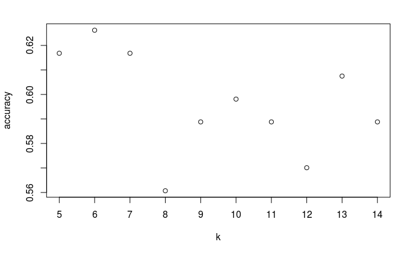

11. (5 pts) Create a plot of k (x-axis) versus error rate (percentage of incorrect classifications) using ggplot.

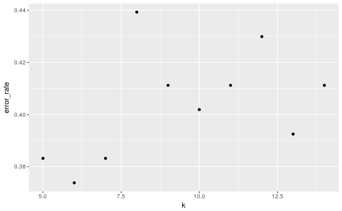

```r
library(ggplot2)
error <- rep(1, each=10)
error_rate <- error - accuracy
qplot(k,error_rate)
```

12. (5 pts) Produce a cross-table confusion matrix showing the accuracy of the classification using a package of your choice and a k of your choice.

```r
test_pred11 <- knn(train = train_n, test = test_n, cl = train_labels, k=6)
confusionMatrix(test_pred11, prc_test_labels)
```

```
Confusion Matrix and Statistics

          Reference
Prediction  1  2  3  5  6  7
         1 29 15  5  1  0  1
         2  4 21  4  2  2  1
         3  2  1  0  0  1  0
         5  0  0  0  2  0  1
         6  0  0  0  0  2  0
         7  0  1  0  1  0 11

Overall Statistics

               Accuracy : 0.6075
                 95% CI : (0.5084, 0.7005)
    No Information Rate : 0.3551
    P-Value [Acc > NIR] : 9.574e-08

                  Kappa : 0.447
 Mcnemar's Test P-Value : NA

Statistics by Class:

                     Class: 1 Class: 2 Class: 3 Class: 5 Class: 6 Class: 7
Sensitivity            0.8286   0.5526  0.00000  0.33333  0.40000   0.7857
Specificity            0.6944   0.8116  0.95918  0.99010  1.00000   0.9785
Pos Pred Value         0.5686   0.6176  0.00000  0.66667  1.00000   0.8462
Neg Pred Value         0.8929   0.7671  0.91262  0.96154  0.97143   0.9681
Prevalence             0.3271   0.3551  0.08411  0.05607  0.04673   0.1308
Detection Rate         0.2710   0.1963  0.00000  0.01869  0.01869   0.1028
Detection Prevalence   0.4766   0.3178  0.03738  0.02804  0.01869   0.1215
Balanced Accuracy      0.7615   0.6821  0.47959  0.66172  0.70000   0.8821
```

13. (3 pts) Comment on the run-time complexity of the k-NN for classifying w new cases using a training data set of n cases having m features. Assume that m is “large”. How does this algorithm behave as w, n, and m increase? Would this algorithm be “fast” if the training data set and the number of features are large?

The run-time is positively correlated with the size of the training(n), the number of new cases(w) and the features(m). If w, n and m increase, the run-time of the algorith will increase. The algorith would not be “fast” if the training data set and the number of features are large.

```r
act_house$price
```

```
[1] 322500
```

2. How would you evaluate the model? While you need to only describe how to evaluate the model, you may calculate an actual metric

We can evaluate the model by using it with the testing data set and calculating an error metric such as Mean Absolute Deviation (MAD) or Mean Squared Error (MSE). The model is said to be a good one if the error metrics are low.

3. 1. (10 pts) Inspect the data set of occupancy rates for a series of time periods. Which forecasting method is most appropriate to use for forecast the next time period? Calculate a forecast for the next time period with a 95% prediction interval. Comment on the bias of your forecasting model.

There are no trends in this dataset and so a simple moving average seems the most appropriate forecasting method. The range of the forecast for the next time period using 3- period simple moving average is from 22.42 to 40.91. The Mean Absolute Deviation is 5.89. Since the bias is not too strong, the moving average seems to be a suitable forecasting model.

```r
occ_rate <- read.csv('occupancyratestimeseries.csv')
plot(occ_rate$Period, occ_rate$OccupancyRate)

### Simple moving average (used 3-period)
n <- nrow(occ_rate)
last3 <- occ_rate[n:(n-2),2]
SMA <- mean(last3)
SMA

occ_rate$Ft <- 0
# Forecasting
for (i in 4:nrow(occ_rate)){
  occ_rate$Ft[i] <- (occ_rate$OccupancyRate[i-1]+ occ_rate$OccupancyRate[i-2]+occ_rate$OccupancyRate[i-3])/3
}
# Make a new column for Square error and initially put all values 0
occ_rate$E <- 0
# Calculating mean absolute deviaion for the forecasts
for (i in 4:nrow(occ_rate)){ # starting from 3rd row since there are no forecasts for the first 2 rows
  occ_rate$E[i] <- abs(occ_rate$OccupancyRate[i]-occ_rate$Ft[i])
}
# Taking mean using 163 observations since there are only 163 forecasts
MAD <- (sum(occ_rate$E))/163
MAD

# Forecast for the next time period with a 95% prediction interval
D <- 0.8*MAD
D
#CI = SMA +- (1.96*D)
CI1 <- SMA - (1.96*D)
CI1
CI2 <- SMA + (1.96*D)
CI2
```

[output not shown]